# Project 001 Memo

Regional differences in adult asthma admission: hospital-level logistic GLMM

Prepared by Miss V · The V Lab

October 09, 2026

MemoA08

ClientDr. ABC

Client OrganizationABC Department

Version1.0

StatusDraft

ClassificationInternal use only

**Note:** Shared synthetic NACRS/DAD data. Real hospital names are reference labels only; all patient records and outcomes are simulated.

# 1 Overview

## 1.1 Research questions

**Primary question:** After adjustment for patient risk, does the probability of admission for adult asthma ED patients differ between hospitals in the Calgary region, the Edmonton region, and other regions? **Secondary question:** Does the admission difference between asthma and non-asthma visits vary by hospital region?

The analysis uses **24,926** adult ED visits from the project’s shared synthetic NACRS/DAD data, including **8,170** asthma visits, across 30 hospitals. A08 does not reuse A06’s matched subset, so that the regional comparison is not affected by match selection made for a different question.

**Simulation only.** Hospital names and the official ED service directory are real public reference information; hospital IDs, patient distributions, admission rates, and regional effects are all simulated. A higher or lower admission rate does not directly indicate quality of care, and this memo does not evaluate or rank any real hospital.

# 2 Hospital reference and region definitions

As specified for this project, Calgary and Edmonton use **regional boundaries that include surrounding towns**. The grouping follows public AHS geographic materials as a fixed study definition and does not claim to represent the current administrative structure. `hospital_city` keeps the specific municipality. Other consists of the selected Central, North, and South hospitals. The 10 hospitals per group are a deliberately chosen teaching sample, not all hospitals, and do not reflect real hospital weights.

All selected facilities are listed in the [AHS Emergency Services directory](https://www.albertahealthservices.ca/findhealth/service.aspx?id=6915). The source and verification date for each hospital are stored in the `hospital_reference` sheet of both Excel workbooks and in `config/hospital_reference.csv`. The directory was checked on **2026-10-09**; being “listed with an ED” does not guarantee there were no temporary service changes at any given time.

This study does not automatically classify Urgent Care as an ED and does not include dedicated children’s hospitals. Strathcona Community Hospital does have an ED, but it was not selected for this round’s simplified same-hospital admission sample; its absence from the list does not mean the hospital has no ED. [Strathcona ED listing](https://www.albertahealthservices.ca/findhealth/Service.aspx?id=6915&serviceAtFacilityID=1101591)

Selected ED facilities; click a hospital name for its official ED source. All clinical records and results are simulated.

| hospital_id | hospital_name | hospital_city | hospital_region | ed_service_listed |
| --- | --- | --- | --- | --- |
| H001 | [Red Deer Regional Hospital Centre](https://www.albertahealthservices.ca/findhealth/Service.aspx?id=6915&serviceAtFacilityID=1075699) | Red Deer | Other | 1 |
| H002 | [Lacombe Hospital and Care Centre](https://www.albertahealthservices.ca/findhealth/Service.aspx?id=6915&serviceAtFacilityID=1075695) | Lacombe | Other | 1 |
| H003 | [Drumheller Health Centre](https://www.albertahealthservices.ca/findhealth/Service.aspx?id=6915&serviceAtFacilityID=1075690) | Drumheller | Other | 1 |
| H004 | [Stettler Hospital and Care Centre](https://www.albertahealthservices.ca/findhealth/Service.aspx?id=6915&serviceAtFacilityID=1116569) | Stettler | Other | 1 |
| H005 | [Grande Prairie Regional Hospital](https://www.albertahealthservices.ca/findhealth/Service.aspx?id=6915&serviceAtFacilityID=1131046) | Grande Prairie | Other | 1 |
| H006 | [Northern Lights Regional Health Centre](https://www.albertahealthservices.ca/findhealth/Service.aspx?id=6915&serviceAtFacilityID=1075677) | Fort McMurray | Other | 1 |
| H007 | [Marshall Eliuk Peace River Community Health Centre](https://www.albertahealthservices.ca/findhealth/Service.aspx?id=6915&serviceAtFacilityID=1075608) | Peace River | Other | 1 |
| H008 | [Chinook Regional Hospital](https://www.albertahealthservices.ca/findhealth/Service.aspx?id=6915&serviceAtFacilityID=1075565) | Lethbridge | Other | 1 |
| H009 | [Medicine Hat Regional Hospital](https://www.albertahealthservices.ca/findhealth/Service.aspx?id=6915&serviceAtFacilityID=1075552) | Medicine Hat | Other | 1 |
| H010 | [Brooks Health Centre](https://www.albertahealthservices.ca/findhealth/Service.aspx?id=6915&serviceAtFacilityID=1075551) | Brooks | Other | 1 |
| H011 | [Foothills Medical Centre](https://www.albertahealthservices.ca/findhealth/Service.aspx?id=6915&serviceAtFacilityID=1075657) | Calgary | Calgary | 1 |
| H012 | [Peter Lougheed Centre](https://www.albertahealthservices.ca/findhealth/Service.aspx?id=6915&serviceAtFacilityID=1075660) | Calgary | Calgary | 1 |
| H013 | [Rockyview General Hospital](https://www.albertahealthservices.ca/findhealth/Service.aspx?id=6915&serviceAtFacilityID=1075661) | Calgary | Calgary | 1 |
| H014 | [South Health Campus](https://www.albertahealthservices.ca/findhealth/Service.aspx?id=6915&serviceAtFacilityID=1093553) | Calgary | Calgary | 1 |
| H015 | [Canmore General Hospital](https://www.albertahealthservices.ca/findhealth/Service.aspx?id=6915&serviceAtFacilityID=1075653) | Canmore | Calgary | 1 |
| H016 | [Mineral Springs Hospital](https://www.albertahealthservices.ca/findhealth/service.aspx?id=6915) | Banff | Calgary | 1 |
| H017 | [High River General Hospital](https://www.albertahealthservices.ca/findhealth/Service.aspx?id=6915&serviceAtFacilityID=1075658) | High River | Calgary | 1 |
| H018 | [Didsbury District Health Services](https://www.albertahealthservices.ca/findhealth/Service.aspx?id=6915&serviceAtFacilityID=1075655) | Didsbury | Calgary | 1 |
| H019 | [Strathmore District Health Services](https://www.albertahealthservices.ca/findhealth/Service.aspx?id=6915&serviceAtFacilityID=1075662) | Strathmore | Calgary | 1 |
| H020 | [Oilfields General Hospital](https://www.albertahealthservices.ca/findhealth/Service.aspx?id=6915&serviceAtFacilityID=1079572) | Diamond Valley | Calgary | 1 |
| H021 | [University of Alberta Hospital](https://www.albertahealthservices.ca/findhealth/Service.aspx?id=6915&serviceAtFacilityID=1005220) | Edmonton | Edmonton | 1 |
| H022 | [Royal Alexandra Hospital](https://www.albertahealthservices.ca/findhealth/Service.aspx?id=6915&serviceAtFacilityID=1006882) | Edmonton | Edmonton | 1 |
| H023 | [Grey Nuns Community Hospital](https://www.albertahealthservices.ca/findhealth/Service.aspx?id=6915&serviceAtFacilityID=8192) | Edmonton | Edmonton | 1 |
| H024 | [Misericordia Community Hospital](https://www.albertahealthservices.ca/findhealth/Service.aspx?id=6915&serviceAtFacilityID=1006883) | Edmonton | Edmonton | 1 |
| H025 | [Sturgeon Community Hospital](https://www.albertahealthservices.ca/findhealth/Service.aspx?id=6915&serviceAtFacilityID=1006878) | St. Albert | Edmonton | 1 |
| H026 | [Redwater Health Centre](https://www.albertahealthservices.ca/findhealth/Service.aspx?id=6915&serviceAtFacilityID=1017907) | Redwater | Edmonton | 1 |
| H027 | [Leduc Community Hospital](https://www.albertahealthservices.ca/findhealth/Service.aspx?id=6915&serviceAtFacilityID=1006880) | Leduc | Edmonton | 1 |
| H028 | [WestView Hospital and Continuing Care Centre](https://www.albertahealthservices.ca/findhealth/Service.aspx?id=6915&serviceAtFacilityID=1017908) | Stony Plain | Edmonton | 1 |
| H029 | [Fort Saskatchewan Community Hospital](https://www.albertahealthservices.ca/findhealth/Service.aspx?id=6915&serviceAtFacilityID=1017906) | Fort Saskatchewan | Edmonton | 1 |
| H030 | [Devon General Hospital](https://www.albertahealthservices.ca/findhealth/Service.aspx?id=6915&serviceAtFacilityID=1039627) | Devon | Edmonton | 1 |

| Region | Adults | Asthma | Admissions | Asthma_admissions | Hospitals | Crude asthma admission risk |
| --- | --- | --- | --- | --- | --- | --- |
| Other | 7622 | 2661 | 1800 | 911 | 10 | 34.2% |
| Calgary | 8585 | 2690 | 1735 | 725 | 10 | 27.0% |
| Edmonton | 8719 | 2819 | 2072 | 1094 | 10 | 38.8% |

# 3 Primary model: asthma patients

The primary analysis includes only patients aged ≥18 with a main diagnosis of J45; the outcome is admission following this ED visit.

```
admitted_flag ~ hospital_region + age10 + sex + smoking + obesity
 + cardiometabolic_history + asthma_history + prior_ed_visits
 + patient_residence + season + ed_arrival_severity + (1 | hospital_id)
```

A **binomial / logit GLMM** is used: region is a fixed effect with Other as the reference, and hospital enters as a normally distributed random intercept. Patients at the same hospital share one baseline admission propensity. With only three regions, region is not treated as a random effect. An ordinary linear mixed model is not used for the binary admission outcome. [lme4 model documentation](https://lme4.github.io/lme4/reference/glmer.html)

Because this question compares hospital regions, it adjusts for the simulated arrival severity, which is measured before treatment and is comparable across hospitals. This severity is downstream of the current asthma episode, so the A06/A07 total-effect analyses of asthma do not adjust for it; a variable’s role depends on the research question. A real study would first need to confirm when severity is measured and that it is consistent across hospitals, and could not simply substitute a post-treatment hospital measure.

## 3.1 Standardized risks and contrasts

Risks are standardized to the shared empirical patient mix of all adult asthma visits, with each patient weighted equally. In each region’s prediction, the same estimated hospital random-effect distribution is integrated over to obtain the population-average risk across hospitals. **This is not setting the random effect to 0 and calling it a marginal risk**, nor is it weighted by real hospital case volumes. The estimand is the regional difference, for the hospital population described by the model, under a common patient mix.

Asthma-only standardized admission risks and regional risk differences

| Metric | Estimate (%) or RD (pp) | 95% low | 95% high |
| --- | --- | --- | --- |
| A1_Other | 32.93 | 28.97 | 36.04 |
| A1_Calgary | 27.21 | 23.39 | 30.92 |
| A1_Edmonton | 40.16 | 35.60 | 44.68 |
| Calgary_vs_Other | -5.72 | -10.53 | 0.25 |
| Edmonton_vs_Other | 7.23 | 2.16 | 12.99 |

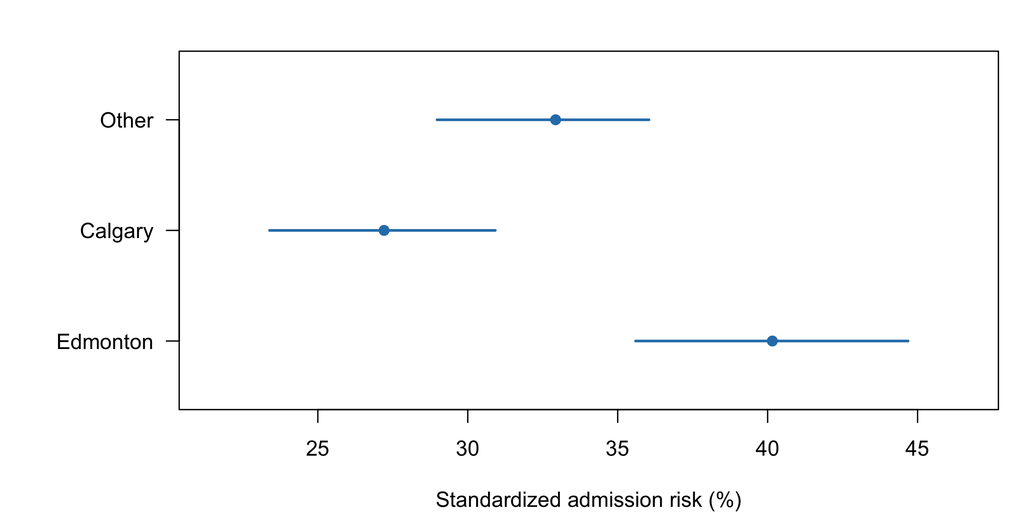

Asthma-only standardized risk; 95% parametric-bootstrap intervals.

The risk difference for Calgary versus Other is **-5.72 percentage points**, 95% CI (-10.53, 0.25); for Edmonton versus Other it is **7.23 percentage points**, 95% CI (2.16, 12.99). These results come from fitting a simulation and cannot be used to infer which real region performs better.

Based on these exploratory intervals, the Calgary versus Other comparison does not yet establish a direction (the interval includes 0); the Edmonton versus Other comparison supports a higher probability of admission. These conclusions apply only to the current simulation and the defined standardization target.

# 4 Secondary model: asthma by region interaction

All adults in the same main NACRS file are used, with the hospital random intercept kept and `asthma_visit * hospital_region` plus pre-visit background factors added. **Arrival severity and CTAS are not added**, so that the severity pathway of asthma is preserved. This question differs from the primary model’s “regional difference among asthma patients of comparable severity”, and the two sets of risk differences should not be conflated.

Same asthma patient background distribution standardized across all three regions

| Metric | RD / difference of RDs (pp) | 95% low | 95% high |
| --- | --- | --- | --- |
| Asthma_RD_Other | 9.55 | 7.42 | 11.62 |
| Asthma_RD_Calgary | 3.50 | 1.66 | 5.16 |
| Asthma_RD_Edmonton | 16.76 | 14.46 | 18.85 |
| RD_difference_Calgary | -6.05 | -8.76 | -3.00 |
| RD_difference_Edmonton | 7.22 | 4.12 | 10.32 |

Regions must be compared directly through the difference in RDs and its interval; “significant in one region but not in another” does not show that regions differ. The joint asthma-by-region interaction test (2 df, log-odds scale) is below; interaction on the log-odds scale and interaction in absolute risk differences are not the same claim.

| Model | npar | AIC | BIC | logLik | -2*log(L) | Chisq | Df | Pr(>Chisq) |
| --- | --- | --- | --- | --- | --- | --- | --- | --- |
| Without asthma × region | 17 | 22727.16 | 22865.26 | -11346.58 | 22693.16 | NA | NA | — |
| With asthma × region | 19 | 22653.13 | 22807.48 | -11307.57 | 22615.13 | 78.0235 | 2 | <1e-04 |

Because the secondary model implicitly averages over unobserved individual severity, its marginal logit form is a working-model approximation. It describes risk-adjusted heterogeneity and does not guarantee recovery of causal effects in real data.

# 5 Uncertainty and model checks

Each model is refitted to 200 parametric bootstrap replicates that regenerate the hospital random effects and binary outcomes while holding the target patient mix fixed. Intervals are the bootstrap 2.5% and 97.5% quantiles and include the uncertainty in the estimated hospital variance; this is not a row-wise independent bootstrap. Seeds are 20261014 for the primary model and 20261015 for the secondary model. [bootMer documentation](https://lme4.github.io/lme4/reference/bootMer.html)

The primary model returned finite estimates in 200/200 replicates and the secondary model in 200/200. Tail quantiles from 200 replicates carry simulation error, and the intervals are not family-wise simultaneous confidence intervals; the multiple regional contrasts are reported as prespecified exploratory results.

Neither bootstrap recorded any fitting messages or warnings.

The models use 9-point adaptive Gauss–Hermite quadrature. Switching the primary model to 17 points changes the fixed effects by at most 2.18e-06. The estimated SD of the hospital random intercept is 0.340, against a generating value of 0.35. The singular-fit check returns FALSE for the primary model and FALSE for the secondary model.

Oracle probabilities used only after fitting, for simulation checking

| Region | Known standardized risk | Estimated risk |
| --- | --- | --- |
| Other | 35.3% | 32.9% |
| Calgary | 27.6% | 27.2% |
| Edmonton | 44.1% | 40.2% |

## 5.1 Repeated known-scenario checks

Separately, 100 simulations were run under each of a positive-effect scenario and a “no systematic regional effect” scenario, each with 6,000 adults and 30 hospitals. The latter sets the region main effects and the asthma-by-region interaction to 0 while keeping random differences between hospitals. The checks cover the conditional regional coefficients of the primary asthma model, Wald interval coverage, and the joint test. This check is not the same as validating the coverage of this memo’s bootstrap intervals 100 times.

| Scenario | Successful | Failed | Calgary_bias | Edmonton_bias | Calgary_coverage | Edmonton_coverage | Joint_rejection | Singular | Warning_runs |
| --- | --- | --- | --- | --- | --- | --- | --- | --- | --- |
| positive | 100 | 0 | 0.045 | 0.081 | 95.0% | 92.0% | 93.0% | 1 | 0 |
| region_null | 100 | 0 | 0.054 | 0.077 | 95.0% | 95.0% | 3.0% | 1 | 0 |

The simulation is only a finite-sample methods check. Complete failures, convergence warnings, and boundary fits are kept in the result bundle, and seeds were not changed in response to results.

# 6 Interpretation and limitations

The probability of admission is affected by illness, referral, bed availability, and case mix; neither a higher nor a lower rate means a hospital is “better”. Admission is currently simplified to admission at the same hospital; a real study should specify transfers, observation beds, and the final admitting hospital. Real hospital weights, service scope, and case volumes did not enter the generating mechanism.

The GLMM handles hospital clustering and some observed differences, but by itself it cannot turn the regional comparison into causal inference. Common support, unmeasured confounding, the timing of diagnosis recording, and the hospital selection mechanism still need independent justification. The 30 deliberately selected facilities cannot directly represent all of Alberta.

# 7 Reproducibility

The only observed data source is the shared NACRS/DAD Excel workbooks. Case data, the public hospital reference table, counterfactual truth, and methods simulations each have a defined purpose; the truth and the hospital random effects used at generation never enter fitting. A08’s input checks match A06/A07, and the full models, bootstrap, and validation results are saved in `outputs/asthma_a08/`.

Back to project home · Data definitions A00 · Matching A06 · Outcome regression A07